# Norway 10A2 Skallneset AG Mytilus edulis SB

### Assessment plots and statistical analysis

This report provides details of the assessment of silver concentrations in blue mussel soft body at station 10A2 Skallnes, Outer Varangerfjord.

- Timeseries metadata. Key information about the timeseries.
- Assessment plot. The fitted trend (solid line) with pointwise 90% confidence bands (grey shaded areas). The trend is plotted on the log scale, with the axis labels back-transformed for ease of interpretation. The points are the annual medians of the individual log concentration measurements, with solid circles denoting uncensored values and < denoting less-than values.
- Trend with data. The fitted trend with pointwise 90% confidence bands. The points are the individual concentration measurements, with + denoting uncensored values, d or q denoting values below the limit of detection or quantification and < denoting other less-than values.
- Auxiliary data. The individual concentration measurements with supporting information: mean length of the individuals in the sample; dry weight (%) of the sample; lipid weight (%) of the sample.
- Assessment (related compounds). Assessment plots for all the compounds in the same chemical group measured in blue mussel soft body at this station.
- Data (related compounds). A scatter plot matrix of all the individual concentration measurements for all the compounds in the same chemical group in blue mussel soft body at this station.
- Statistical analysis. This tab summarises the fits of models with different amount of smoothing. The final choice is the model with the minimum AICc (with the caveat that a linear model is always preferred to a mean model if there are sufficient years of data). The tab also gives the contrast between the fitted values at the start and end of the timeseries, and over the most recent twenty years.

#### Timeseries metadata

- OSPAR region: 1
- Region: Barents Sea
- Station code: 10A2 Skallneset
- Station name: 10A2 Skallnes, Outer Varangerfjord
- Station latitude: 70.14
- Station longitude: 30.34
- Compartment: biota
- Species latin name: Mytilus edulis
- Species common name: blue mussel
- Tissue: soft body
- Determinand code: AG
- Determinand name: silver
- Units: μg kg<sup>-1</sup> dry weight
- Extraction: 31 October 2022

#### Assessment plot

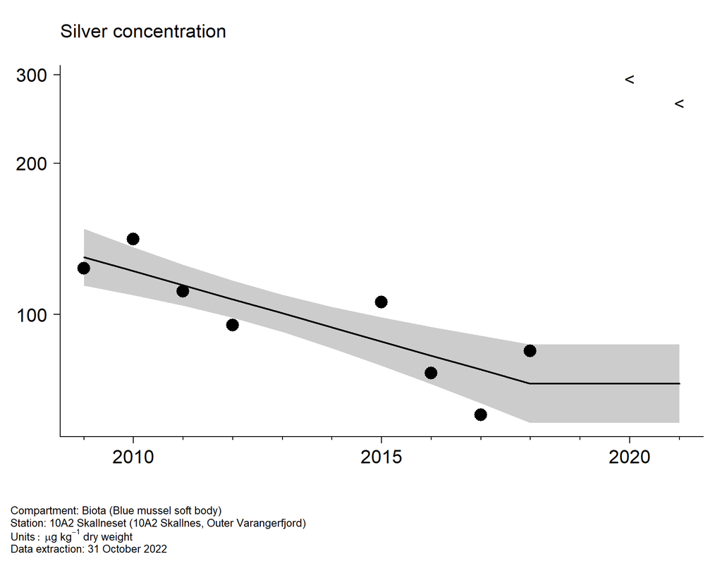

#### Trend with data

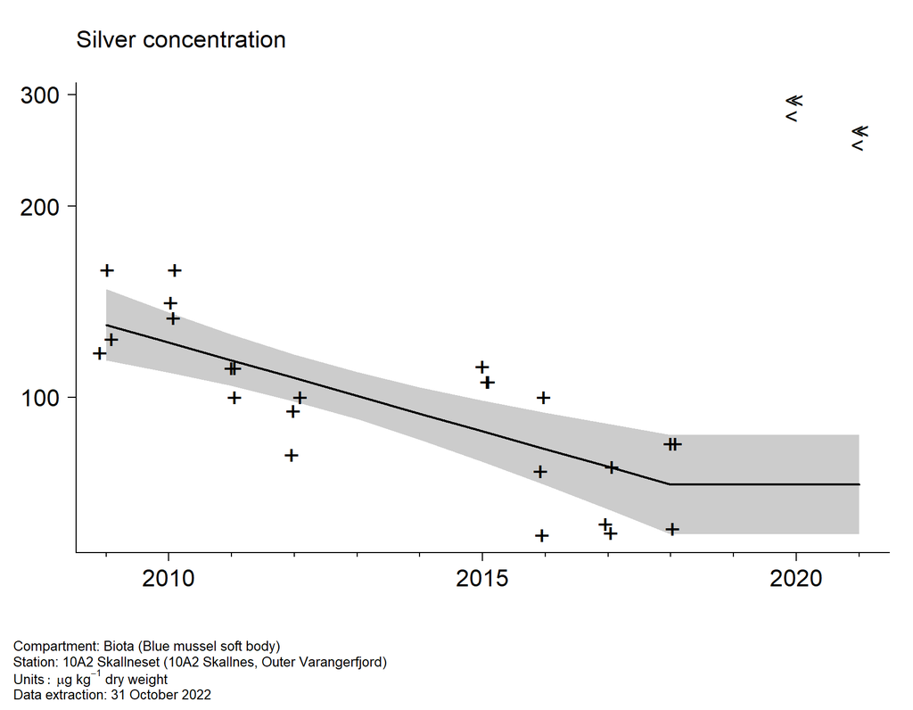

#### Auxiliary data

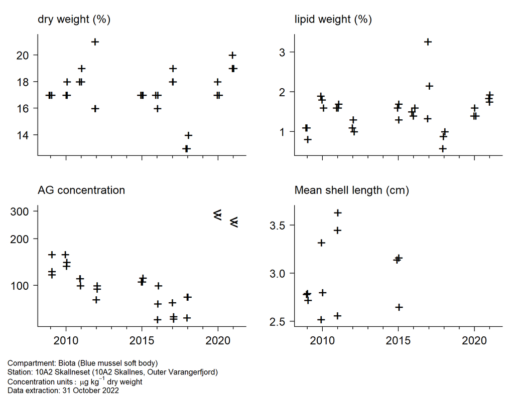

#### Assessments (related compounds)

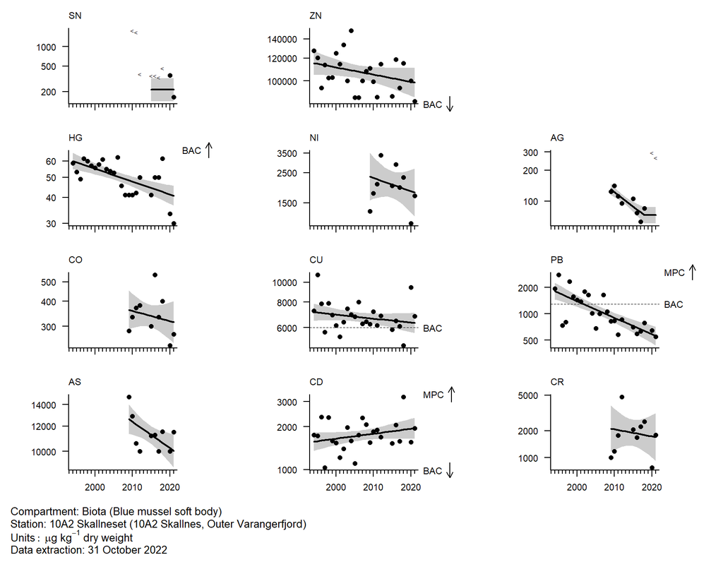

#### Data (related compounds)

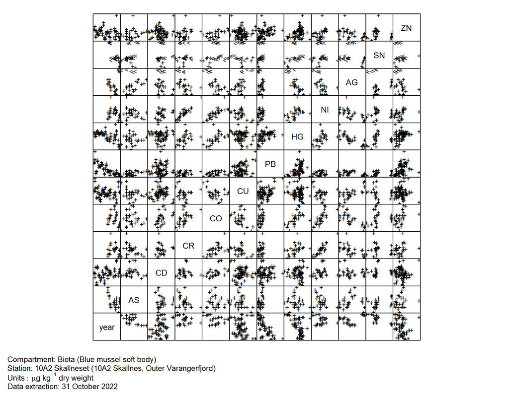

#### Statistical analysis

**Trend assessment**

Analysis of variance

```
                Df        AIC      AICc  Log lik  Deviance     Chisq Chi df  Pr(>Chisq)
mean             1  0.8919797 4.4919797 2.554010  -5.10802        NA     NA          NA
linear           2 -7.4684082 0.5315918 7.734204 -15.46841 10.360388      1 0.001287481
smooth (df = 2)  3 -7.4377001 9.2289666 8.718850 -17.43770  1.969292      1 0.160523047
```

Change in log concentration

```
              Year start Year end Fit start  Fit end     Change Std error         t    Pr(>|t|)
overall             2009     2021    4.8685 4.288963 -0.5795368 0.1328473 -4.362429 0.004757931
last 20 years       2009     2021    4.8685 4.288963 -0.5795368 0.1328473 -4.362429 0.004757931
```

**Status assessment**

There are no assessment criteria so no status assessment is possible.

**Interpretation**

There is a significant log-linear trend in the time series (p = 0.0013). Concentrations have decreased by an estimated -4.7% per year over the course of the time series.